# Final Project CS101 BSIT2B Group7

Zydrick Ceniza, Aira Mia Lego

2023-12-20

# Final Project CS101 BSIT2B Group7

```r
library(rvest)
library(httr)
library(dplyr)
library(polite)


polite::use_manners(save_as = 'polite_scrape.R')
```

```
## ✔ Setting active project to '/cloud/project'
```

```r
url <- 'https://www.airlinequality.com/airline-reviews/airasia/'
session <- bow(url,
               user_agent = "Educational")




title <- character(0)


titles_list <- scrape(session) %>%
  html_nodes('h3.text_sub_header') %>%
  html_text

titles_list_sub <- as.data.frame(titles_list[1:10])
colnames(titles_list_sub) <- "ranks"


split_df <- strsplit((titles_list_sub$ranks),"\r\n","reviews",fixed = TRUE)
split_df <- data.frame(do.call(rbind,split_df))

title<- data.frame(
  title= split_df)

title<-title[,c(-1,-2,-3)]
split_df <- strsplit((title),"(",fixed = TRUE)
split_df <- data.frame(do.call(rbind,split_df))
name<-as.data.frame(split_df[,1])

split_df <- strsplit((split_df$X2),")",fixed = TRUE)
split_df <- data.frame(do.call(rbind,split_df))
num1<-cbind(name,split_df)



xname<-array(2:30)
xone<-array(2:30)
xtwo<-array(2:30)

for (i in 2:30) {
  url<-paste("https://www.airlinequality.com/airline-reviews/airasia/page/",i,"/", sep = "")

  session <- bow(url,
                 user_agent = "Educational")


  title <- character(0)


  titles_list <- scrape(session) %>%
    html_nodes('h3.text_sub_header') %>%
    html_text

  titles_list_sub <- as.data.frame(titles_list[1:10])
  colnames(titles_list_sub) <- "ranks"


  split_df <- strsplit((titles_list_sub$ranks),"\r\n","reviews",fixed = TRUE)
  split_df <- data.frame(do.call(rbind,split_df))

  title<- data.frame(
    title= split_df)
  title
  title<-title[,c(-1,-2,-3)]
  title
  split_df<- strsplit((title),"(",fixed = TRUE)
  split_df<- data.frame(do.call(rbind,split_df))

  name<-as.data.frame(split_df[,1])

  split_df<- strsplit((split_df$X2),")",fixed = TRUE)
  split_df<- data.frame(do.call(rbind,split_df))

  xname[i]<-name
  xone[i]<-as.data.frame(split_df$X1)
  xtwo[i]<-as.data.frame(split_df$X2)
}
for (i in 2:30){
  df1<-data.frame(
    data=c(xone[i])
  )
  colnames(df1)<-"data"

  if(i==2){
    resc<-df1
  }
  else if(i>2){
    resc<-rbind(resc,df1)
  }
}

for (i in 2:30){
  df1<-data.frame(
    data=c(xname[i])
  )
  colnames(df1)<-"data"

  if(i==2){
    resn<-df1
  }
  else if(i>2){
    resn<-rbind(resn,df1)
  }
}

for (i in 2:30){
  df1<-data.frame(
    data=c(xtwo[i])
  )
  colnames(df1)<-"data"

  if(i==2){
    resd<-df1
  }
  else if(i>2){
    resd<-rbind(resd,df1)
  }
}
num2<-cbind(resn,resc,resd)
colnames(num1)<-c("Name","Country","Date")
colnames(num2)<-c("Name","Country","Date")
part3<-rbind(as.data.frame(num1),as.data.frame(num2))

#-----------------------------------------------------------------------
name <- character(0)

title_list <- scrape(session) %>%
  html_nodes('td.review-value') %>%
  html_text
title_list_sub <- as.data.frame(title_list[])


name<- title_list_sub
colnames(name)<-c("Name")

split_df <- strsplit((name[,1]),"|", fixed = TRUE)
split_df <- data.frame(do.call(rbind,split_df))

colnames(split_df)<-"details"

split_df<-subset(split_df, details!="A320")
b1y5<-seq(1,50,by=5)
g1<-as.data.frame(split_df[b1y5,])
b2y5<-seq(2,50,by=5)
g2<-as.data.frame(split_df[b2y5,])

b3y5<-seq(3,50,by=5)
g3<-as.data.frame(split_df[b3y5,])



b4y5<-seq(4,50,by=5)
g4<-as.data.frame(split_df[b4y5,])
b5y5<-seq(5,50,by=5)
g5<-as.data.frame(split_df[b5y5,])

group1<-cbind(g1,g2,g3,g4,g5)

gc1<-array(2:30)
gc2<-array(2:30)
gc3<-array(2:30)
gc4<-array(2:30)
gc5<-array(2:30)

# Example for loop
for (i in 2:30) {
  url<-paste("https://www.airlinequality.com/airline-reviews/airasia/page/",i,"/", sep = "")

  session <- bow(url,
                 user_agent = "Educational")


  group<- character(0)


  group_list <- scrape(session) %>%
    html_nodes('td.review-value') %>%
    html_text

  group_list_sub <- as.data.frame(group_list[])
  colnames(group_list_sub) <- "details"

  split_df<-subset(group_list_sub, details!="A320" & details!="A320-200" & details!="Airbu" & details!="A320 Neo" & details!="A330" & details!="A330-300" & details!="A330 Neo" & details!="a320" & details!="AirAsia airline")
  b1y5<-seq(1,50,by=5)
  g1<-as.data.frame(split_df[b1y5,])
  colnames(g1)<-c("TypeofTraveller")
  gc1[i]<-g1

  b2y5<-seq(2,50,by=5)
  g2<-as.data.frame(split_df[b2y5,])
  colnames(g2)<-c("SeatType")
  gc2[i]<-g2

  b3y5<-seq(3,50,by=5)
  gc3[i]<-as.data.frame(split_df[b3y5,])


  b4y5<-seq(4,50,by=5)
  g4<-as.data.frame(split_df[b4y5,])
  gc4[i]<-g4

  b5y5<-seq(5,50,by=5)
  g5<-as.data.frame(split_df[b5y5,])
  gc5[i]<-g5


}
for (i in 2:30){
  df1<-data.frame(
    data=c(gc1[i])
  )
  colnames(df1)<-"TypeofTraveller"

  if(i==2){
    restot<-df1
  }
  else if(i>2){
    restot<-rbind(restot,df1)
  }
}
for (i in 2:30){
  df2<-data.frame(
    data=c(gc2[i])
  )
  colnames(df2)<-"SeatType"

  if(i==2){
    resst<-df2
  }
  else if(i>2){
    resst<-rbind(resst,df2)
  }
}
for (i in 2:30){
  df3<-data.frame(
    data=c(gc3[i])
  )
  colnames(df3)<-"Route"

  if(i==2){
    resroute<-df3
  }
  else if(i>2){
    resroute<-rbind(resroute,df3)
  }
}
for (i in 2:30){
  df4<-data.frame(
    data=c(gc4[i])
  )
  colnames(df4)<-"DateFlown"

  if(i==2){
    resd<-df4
  }
  else if(i>2){
    resd<-rbind(resd,df4)
  }
}
for (i in 2:30){
  df5<-data.frame(
    data=c(gc5[i])
  )
  colnames(df5)<-"Recomended"

  if(i==2){
    resrec<-df5
  }
  else if(i>2){
    resrec<-rbind(resrec,df5)
  }
}

group2<-cbind(restot,resst,resroute,resd,resrec)
colnames(group1)<-c("TypeofTraveller","SeatType","Route","DateFlown","Recommended")
colnames(group2)<-c("TypeofTraveller","SeatType","Route","DateFlown","Recommended")
part4<-rbind(group1,group2)

#---------------------------------------------------------------------------------
title <- character(0)


titles_list <- scrape(session) %>%
  html_nodes('h2.text_header') %>%
  html_text

titles_list_sub <- as.data.frame(titles_list[1:10])
colnames(titles_list_sub) <- "Title"


title<- data.frame(
  title= titles_list_sub)

tilt<-as.data.frame(title)
split_df <- strsplit((tilt[,1]),"\"", fixed = TRUE)
split_df <- data.frame(do.call(rbind,split_df))
tilt<-split_df
tilt<-tilt[,-1]
tilt<-as.data.frame(tilt)

xtitle<-array(2:30)


for (i in 2:30) {
  url<-paste("https://www.airlinequality.com/airline-reviews/airasia/page/",i,"/", sep = "")

  session <- bow(url,
                 user_agent = "Educational")


  title <- character(0)


  titles_list <- scrape(session) %>%
    html_nodes('h2.text_header') %>%
    html_text

  titles_list_sub <- as.data.frame(titles_list[1:10])
  colnames(titles_list_sub) <- "Title"

  title<- data.frame(
    title= titles_list_sub)

  title<-as.data.frame(title)

  xtitle[i]<-as.data.frame(title[,1])

}
for (i in 2:30){
  df1<-data.frame(
    data=c(xtitle[i])
  )
  colnames(df1)<-"Title"

  if(i==2){
    rest<-df1
  }
  else if(i>2){
    rest<-rbind(rest,df1)
  }
}
colnames(tilt)<-"Title"
part5<-rbind(tilt,rest)

#-------------------------------------------------------------------------------

textrev<- character(0)

treviews <- scrape(session) %>%
  html_nodes('div.text_content') %>%
  html_text
treviews_sub <- as.data.frame(treviews[1:10])


textrev<- treviews_sub


split_df <- strsplit((textrev[,1]),"|", fixed = TRUE)
split_df <- data.frame(do.call(rbind,split_df))



reviews1<-as.data.frame(split_df$X2)



reviews2<-array(2:30)
for (i in 2:30) {

  url<-paste("https://www.airlinequality.com/airline-reviews/airasia/page/",i,"/", sep = "")

  session <- bow(url,
                 user_agent = "Educational")


  textrev2 <- character(0)


  treviews2<- scrape(session) %>%
    html_nodes('div.text_content') %>%
    html_text
  treviews_sub2 <- as.data.frame(treviews2[1:10])

  textrev2<- treviews_sub2


  split_df <- strsplit((textrev2[,1]),"|", fixed = TRUE)
  split_df <- data.frame(do.call(rbind,split_df))

  r1<-split_df
  reviews2[i]<-as.data.frame(split_df$X2)

}

for (i in 2:30){
  dr1<-data.frame(
    data=c(reviews2[i])
  )
  colnames(dr1)<-"Reviews"

  if(i==2){
    resreview<-dr1
  }
  else if(i>2){
    resreview<-rbind(resreview,dr1)
  }
}
reviews1<-as.data.frame(reviews1)
colnames(reviews1)<-"Reviews"
resreview<-as.data.frame(resreview)
colnames(resreview)<-"Reviews"
part6<-rbind(reviews1,resreview)
finaloutput<-cbind(part3,part4,part5,part6)
colnames(finaloutput)<-c("name","country","date","typeoftraveller","seattype","route","dateflown","recommended","title","review")

finaloutput
```

```
##                                                    name        country
## 1                                          Ben Wiseman   United States
## 2                                                 D Po     Philippines
## 3                                               P Yang       Australia
## 4                                          Osman Sadiq       Australia
## 5                                          Craig Cutts  United Kingdom
## 6                                       Dave Deschenes        Thailand
## 7                                         Yoon hye Kim        Malaysia
## 8                                              D Murib       Indonesia
## 9                                            D Parmeel       Australia
## 10                                           C Hawdran       Indonesia
## 11                                             P Craig       Australia
## 12                                               A Gee         Germany
## 13                                            E Carlen   United States
## 14                                               M Lee          Canada
```

[output cut: 1490 more lines]

`Malaysia has the most number of passengers that review the Airasia.`

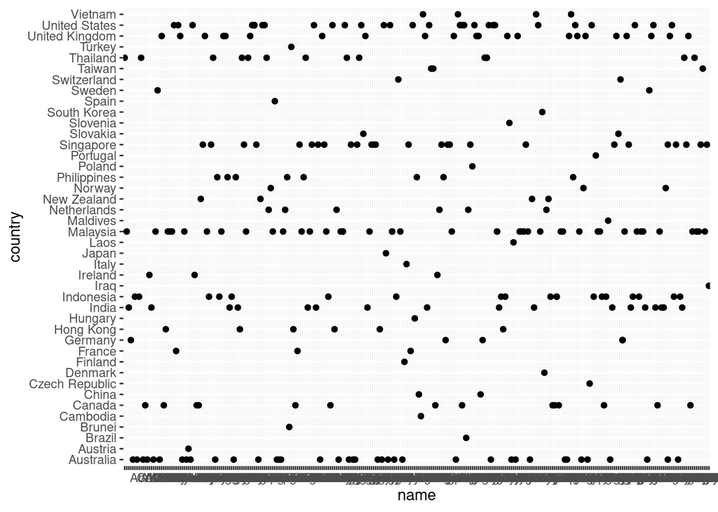

```r
library(ggplot2)
ggplot(finaloutput, aes(x =name, y = country),colors=class) + geom_point()
```

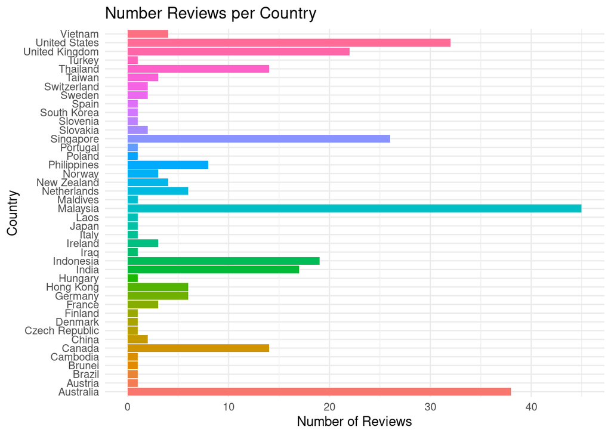

```r
library(ggplot2)

library(dplyr)

groupofcountry<- finaloutput %>%
  group_by(country) %>%
  summarise(count=n())

ggplot(groupofcountry, aes(x = country, y = count, fill = country)) +
  geom_bar(stat = "identity") +
  coord_flip() +
  theme_minimal() +
  labs(title = "Number Reviews per Country",
       x = "Country",
       y = "Number of Reviews") +
  scale_fill_hue()+ guides(fill=FALSE)
```

`Passenger's recommendation reviews to Air Asia Airline. Most passengers prefer/voted to not recommend the airline.`

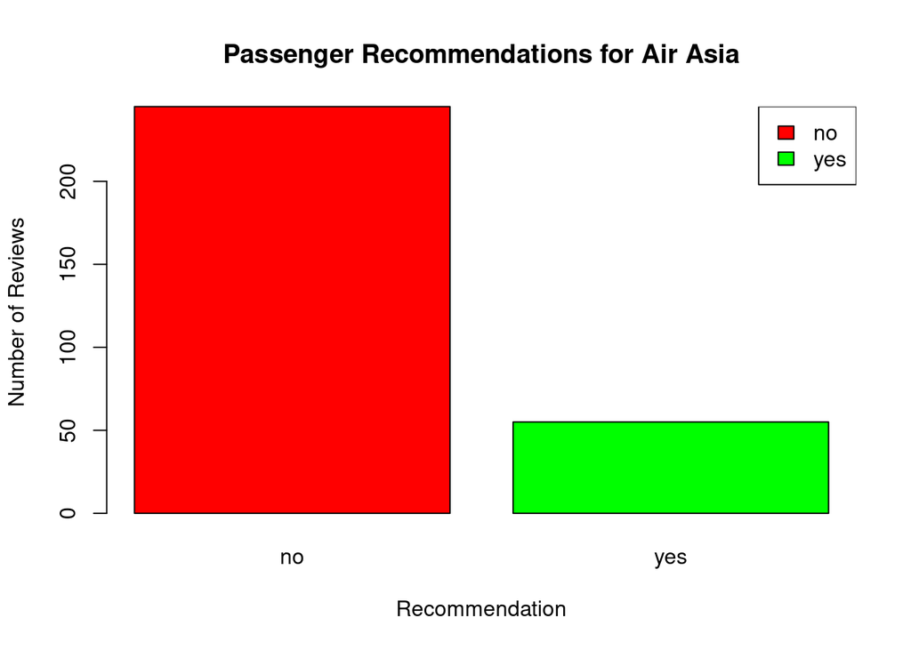

```r
recommendedfactor<-factor(finaloutput$recommended)
barcolors <- c("red", "green")
plot(recommendedfactor,col=c(barcolors),main="Passenger Recommendations for Air Asia",xlab = "Recommendation", ylab = "Number of Reviews")
legend("topright", legend = levels(recommendedfactor), fill = barcolors)
```

`The analysis of passenger data for Air Asia reveals a diverse distribution of traveler types, with 30 business travelers, 70 couples on leisure trips, 86 family leisure , and 114 solo leisure travelers.`

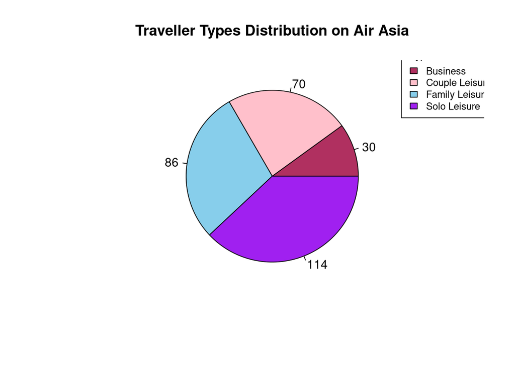

```r
library(dplyr)

groupoftraveller<- finaloutput %>%
  group_by(typeoftraveller) %>%
  summarise(count=n())

colors <- c("maroon", "pink", "skyblue", "purple")


pie(groupoftraveller$count, labels = groupoftraveller$count, col = colors, main = "Traveller Types Distribution on Air Asia")
legend(x = 1.2, y = 1.2,cex = 0.8, legend = groupoftraveller$typeoftraveller, fill = colors, title = "Type of Travellers")
```

`The most word that has been spotted in the comment reviewsis the word flight followed by the airasia,service,refund,airline,time,get,flights, and customer.`

```r
library(wordcloud)
library(tm)
reviewCorpus <- Corpus(VectorSource(finaloutput$review))

reviewCorpus <- tm_map(reviewCorpus, content_transformer(tolower))
reviewCorpus <- tm_map(reviewCorpus, removePunctuation)
reviewCorpus <- tm_map(reviewCorpus, removeNumbers)
reviewCorpus <- tm_map(reviewCorpus, removeWords, stopwords("english"))
reviewCorpus <- tm_map(reviewCorpus, stripWhitespace)
reviewCorpus <- tm_map(reviewCorpus, removeWords, c("the","just","even","will","my","kg", "us", "said", "via"))
str(reviewCorpus)
```

```
## Classes 'SimpleCorpus', 'Corpus'  hidden list of 3
##  $ content: chr [1:300] " singapore jakarta flight jakarta delayed airasia sent email saying option get refund follow steps stated email"| __truncated__ " phuket chiang mai airasia worst service ever experienced aircraft im tall literally sit seat without physicall"| __truncated__ " kuala lumpur …
##  $ meta   :List of 1
##   ..$ language: chr "en"
##   ..- attr(*, "class")= chr "CorpusMeta"
##  $ dmeta  :'data.frame': 300 obs. of  0 variables
```

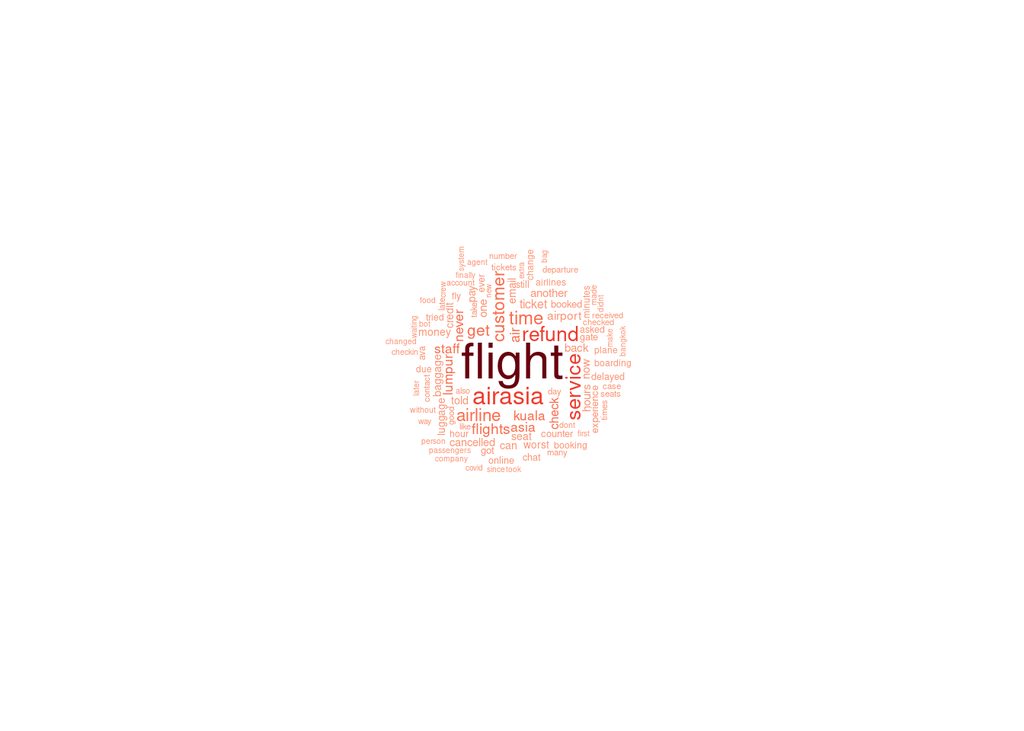

```r
pal <- brewer.pal(9, "Reds")
pal<- pal[-(1:3)]

set.seed(1234)
wordcloud(words = reviewCorpus, min.freq = 1, scale = c(2, 0.2), max.words = 100, random.order = FALSE, rot.per = 0.35, colors = pal)
```

`There are more very positive sentiments with the number of 136 found in AirAsia followed by the very negative=107,negative=37,positive=18,neutral=2.`

```r
library(syuzhet)
library(SentimentAnalysis)
```

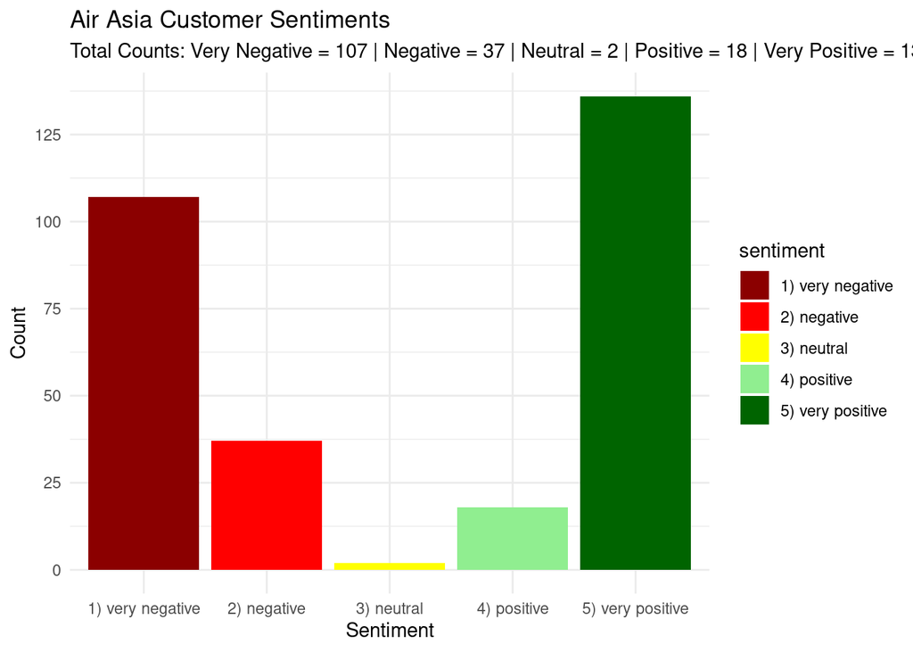

```r
library(ggplot2)
library(SnowballC)

reviewP <- data.frame(text = sapply (reviewCorpus, as.character), stringsAsFactors= FALSE)

reviewSentiments <- get_sentiment (reviewP$text,method = "syuzhet")

reviewsen <- cbind(reviewP, reviewSentiments)

#positive and negative sentiments
reviewsen$sentiment <- ifelse(reviewsen$reviewSentiments <= -0.5, "1) very negative",
                              ifelse(reviewsen$reviewSentiments > -0.5 & reviewsen$reviewSentiments < 0, "2) negative",
                                     ifelse(reviewsen$reviewSentiments == 0, "3) neutral",
                                            ifelse(reviewsen$reviewSentiments > 0 & reviewsen$reviewSentiments < 0.5, "4) positive",
                                                   ifelse(reviewsen$reviewSentiments >= 0.5, "5) very positive", NA)))))
df <- head(reviewsen, n = 10)


sentiment_counts <- table(reviewsen$sentiment)


ggplot(reviewsen, aes(x = sentiment, fill = sentiment)) +
geom_bar() +
  labs(title = "Air Asia Customer Sentiments",
       x = "Sentiment",
       y = "Count",
       subtitle = paste("Total Counts: Very Negative =", sentiment_counts["1) very negative"],
                        "| Negative =", sentiment_counts["2) negative"],
                        "| Neutral =", sentiment_counts["3) neutral"],
                        "| Positive =", sentiment_counts["4) positive"],
                        "| Very Positive =", sentiment_counts["5) very positive"])) +
  scale_fill_manual(values = c("1) very negative" = "darkred",
                               "2) negative" = "red",
                               "3) neutral" = "yellow",
                               "4) positive" = "lightgreen",
                               "5) very positive" = "darkgreen")) +
  scale_y_continuous(breaks = seq(0, 150, 25)) +
  theme_minimal()
```

`The maximum number of the number of reviews per date is in the date of September 26, 2023 that has 6 reviews, followed by 4 reviews in date of February 18,2020, 5counts of 3 reviews per date,30counts of 2 reviews per date, and 215counts per 1 review per date in the remaining dates.`

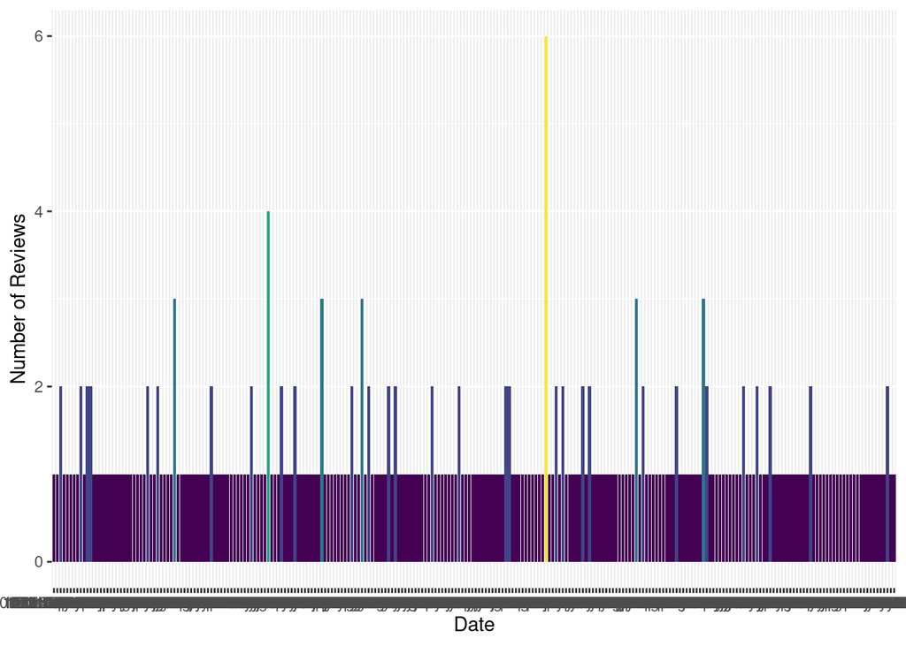

```r
library(ggplot2)
library(viridis)
library(dplyr)
ggplot(data = finaloutput, aes(x = date)) +
  geom_bar(aes(fill = ..count..), stat = "count") +
  theme(legend.position = "none") +
  xlab("Date") + ylab("Number of Reviews") +
  scale_fill_viridis_c()
```

```r
dateof<-finaloutput%>%
  group_by(date)%>%
  summarise(count=n())
md<-max(dateof$count)
subset(dateof,count==md)
```

```
## # A tibble: 1 × 2
##   date                   count
##   <chr>                  <int>
## 1 " 26th September 2023"     6
```

```r
subset(dateof,count==4)
```

```
## # A tibble: 1 × 2
##   date                  count
##   <chr>                 <int>
## 1 " 18th February 2020"     4
```

```r
subset(dateof,count==3)
```

```
## # A tibble: 5 × 2
##   date                  count
##   <chr>                 <int>
## 1 " 14th January 2020"      3
## 2 " 1st April 2020"         3
## 3 " 20th August 2023"       3
## 4 " 2nd September 2019"     3
## 5 " 4th February 2020"      3
```

```r
subset(dateof,count==2)
```

```
## # A tibble: 30 × 2
##    date                   count
##    <chr>                  <int>
##  1 " 10th June 2019"          2
##  2 " 10th September 2023"     2
##  3 " 11th February 2023"      2
##  4 " 11th July 2023"          2
##  5 " 13th November 2019"      2
##  6 " 14th April 2022"         2
##  7 " 16th April 2020"         2
##  8 " 17th March 2023"         2
##  9 " 18th May 2022"           2
## 10 " 18th September 2019"     2
## # ℹ 20 more rows
```

```r
subset(dateof,count==1)
```

```
## # A tibble: 215 × 2
##    date                   count
##    <chr>                  <int>
##  1 " 10th January 2020"       1
##  2 " 10th July 2020"          1
##  3 " 10th June 2022"          1
##  4 " 10th March 2020"         1
##  5 " 10th March 2022"         1
##  6 " 10th November 2023"      1
##  7 " 10th September 2019"     1
##  8 " 11th December 2022"      1
##  9 " 11th June 2021"          1
## 10 " 11th November 2022"      1
## # ℹ 205 more rows
```